# Lab_1

Kim Youngrae

2017 8 8

# Content

- Introduction to R
- Linear Regression
- Exercises

# Introduction to R

- ls() : list of all of the objects.

```r
x=c(1,6,2); y=c(1,4,3);
ls()
```

```
## [1] "x" "y"
```

- rm() : delete object.

```r
rm(x)
ls()
```

```
## [1] "y"
```

- ?funcname : help

```r
?rm
```

- set.seed() : Set seed to allow us to reproduce the same set of random numbers.

```r
rnorm(10)
```

```
##  [1]  0.11611540  1.47084663 -0.47093880 -0.31192548  0.24907521
##  [6]  0.83826639  0.81395459  0.61990963  0.55707628  0.04035043
```

```r
rnorm(10)
```

```
##  [1] -1.0010472  0.6959036  0.2961245 -0.2774818 -0.0690521 -0.5357071
##  [7]  0.4766920  0.7847943  1.2638183 -0.5448102
```

```r
set.seed(1)
rnorm(10)
```

```
##  [1] -0.6264538  0.1836433 -0.8356286  1.5952808  0.3295078 -0.8204684
##  [7]  0.4874291  0.7383247  0.5757814 -0.3053884
```

```r
set.seed(1)
rnorm(10)
```

```
##  [1] -0.6264538  0.1836433 -0.8356286  1.5952808  0.3295078 -0.8204684
##  [7]  0.4874291  0.7383247  0.5757814 -0.3053884
```

- library() : load the package

```r
library(MASS)
```

- read.table() : import data ( read.csv, …)

```r
read.table("\경로와 파일 이름",header=TRUE)
```

- ggplot : package for graphics

```r
library(ggplot2)
```

# Linear Regression

- lm() : linear model, for regression

```r
library(MASS)
library(ISLR)
```

```r
lm.fit<-lm(medv~lstat,data=Boston)
summary(lm.fit)
```

```
##
## Call:
## lm(formula = medv ~ lstat, data = Boston)
##
## Residuals:
##     Min      1Q  Median      3Q     Max
## -15.168  -3.990  -1.318   2.034  24.500
##
## Coefficients:
##             Estimate Std. Error t value Pr(>|t|)
## (Intercept) 34.55384    0.56263   61.41   <2e-16 ***
## lstat       -0.95005    0.03873  -24.53   <2e-16 ***
## ---
## Signif. codes:  0 '***' 0.001 '**' 0.01 '*' 0.05 '.' 0.1 ' ' 1
##
## Residual standard error: 6.216 on 504 degrees of freedom
## Multiple R-squared:  0.5441, Adjusted R-squared:  0.5432
## F-statistic: 601.6 on 1 and 504 DF,  p-value: < 2.2e-16
```

```r
confint(lm.fit)
```

```
##                 2.5 %     97.5 %
## (Intercept) 33.448457 35.6592247
## lstat       -1.026148 -0.8739505
```

```r
predict(lm.fit)
```

[output not shown]

[output cut: 115 more lines]

[output not shown]

```r
predict(lm.fit,interval='prediction')
```

```
##            fit         lwr      upr
## 1   29.8225951  17.5846032 42.06059
## 2   25.8703898  13.6434129 38.09737
## 3   30.7251420  18.4834878 42.96680
## 4   31.7606958  19.5143151 44.00708
## 5   29.4900778  17.2533279 41.72683
## 6   29.6040837  17.3669145 41.84125
## 7   22.7447274  10.5206618 34.96879
## 8   16.3603958   4.1263477 28.59444
## 9    6.1188637  -6.1756909 18.41342
## 10  18.3079969   6.0792598 30.53673
## 11  15.1253316   2.8868863 27.36378
## 12  21.9466860   9.7225420 34.17083
## 13  19.6285655   7.4022984 31.85483
## 14  26.7064332  14.4778089 38.93506
```

[output cut: 492 more lines]

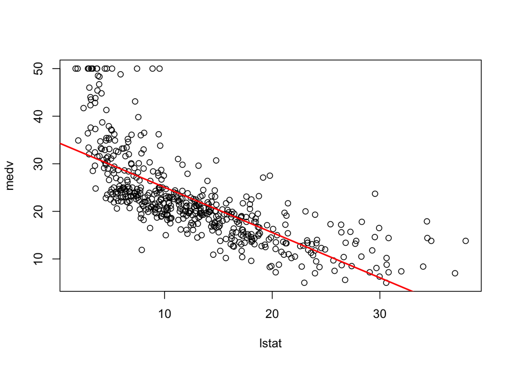

```r
attach(Boston)
plot(lstat,medv)
abline(lm.fit,col="red",lwd="2")
```

```r
lm.fit<-lm(medv~lstat+age,data=Boston)
summary(lm.fit)
```

```
##
## Call:
## lm(formula = medv ~ lstat + age, data = Boston)
##
## Residuals:
##     Min      1Q  Median      3Q     Max
## -15.981  -3.978  -1.283   1.968  23.158
##
## Coefficients:
##             Estimate Std. Error t value Pr(>|t|)
## (Intercept) 33.22276    0.73085  45.458  < 2e-16 ***
## lstat       -1.03207    0.04819 -21.416  < 2e-16 ***
## age          0.03454    0.01223   2.826  0.00491 **
## ---
## Signif. codes:  0 '***' 0.001 '**' 0.01 '*' 0.05 '.' 0.1 ' ' 1
##
## Residual standard error: 6.173 on 503 degrees of freedom
## Multiple R-squared:  0.5513, Adjusted R-squared:  0.5495
## F-statistic:   309 on 2 and 503 DF,  p-value: < 2.2e-16
```

```r
confint(lm.fit)
```

```
##                   2.5 %      97.5 %
## (Intercept) 31.78687150 34.65864956
## lstat       -1.12674848 -0.93738865
## age          0.01052507  0.05856361
```

```r
predict(lm.fit)
```

[output not shown]

[output cut: 115 more lines]

[output not shown]

```r
lm.fit<-lm(medv~.,data=Boston)
summary(lm.fit)
```

```
##
## Call:
## lm(formula = medv ~ ., data = Boston)
##
## Residuals:
##     Min      1Q  Median      3Q     Max
## -15.595  -2.730  -0.518   1.777  26.199
##
## Coefficients:
##               Estimate Std. Error t value Pr(>|t|)
## (Intercept)  3.646e+01  5.103e+00   7.144 3.28e-12 ***
## crim        -1.080e-01  3.286e-02  -3.287 0.001087 **
## zn           4.642e-02  1.373e-02   3.382 0.000778 ***
## indus        2.056e-02  6.150e-02   0.334 0.738288
## chas         2.687e+00  8.616e-01   3.118 0.001925 **
## nox         -1.777e+01  3.820e+00  -4.651 4.25e-06 ***
## rm           3.810e+00  4.179e-01   9.116  < 2e-16 ***
## age          6.922e-04  1.321e-02   0.052 0.958229
## dis         -1.476e+00  1.995e-01  -7.398 6.01e-13 ***
## rad          3.060e-01  6.635e-02   4.613 5.07e-06 ***
## tax         -1.233e-02  3.760e-03  -3.280 0.001112 **
## ptratio     -9.527e-01  1.308e-01  -7.283 1.31e-12 ***
## black        9.312e-03  2.686e-03   3.467 0.000573 ***
## lstat       -5.248e-01  5.072e-02 -10.347  < 2e-16 ***
## ---
## Signif. codes:  0 '***' 0.001 '**' 0.01 '*' 0.05 '.' 0.1 ' ' 1
##
## Residual standard error: 4.745 on 492 degrees of freedom
## Multiple R-squared:  0.7406, Adjusted R-squared:  0.7338
## F-statistic: 108.1 on 13 and 492 DF,  p-value: < 2.2e-16
```

```r
lm.fit<-lm(medv~.+0,data=Boston)
summary(lm.fit)
```

```
##
## Call:
## lm(formula = medv ~ . + 0, data = Boston)
##
## Residuals:
##      Min       1Q   Median       3Q      Max
## -21.1100  -2.5630  -0.5529   1.6546  30.7254
##
## Coefficients:
##          Estimate Std. Error t value Pr(>|t|)
## crim    -0.092897   0.034421  -2.699 0.007197 **
## zn       0.048715   0.014403   3.382 0.000776 ***
## indus   -0.004060   0.064440  -0.063 0.949789
## chas     2.853999   0.903913   3.157 0.001689 **
## nox     -2.868436   3.358732  -0.854 0.393507
## rm       5.928148   0.309109  19.178  < 2e-16 ***
## age     -0.007269   0.013815  -0.526 0.598979
## dis     -0.968514   0.195630  -4.951 1.02e-06 ***
## rad      0.171151   0.066752   2.564 0.010644 *
## tax     -0.009396   0.003923  -2.395 0.016988 *
## ptratio -0.392191   0.109869  -3.570 0.000393 ***
## black    0.014906   0.002697   5.528 5.27e-08 ***
## lstat   -0.416304   0.050786  -8.197 2.14e-15 ***
## ---
## Signif. codes:  0 '***' 0.001 '**' 0.01 '*' 0.05 '.' 0.1 ' ' 1
##
## Residual standard error: 4.98 on 493 degrees of freedom
## Multiple R-squared:  0.9592, Adjusted R-squared:  0.9581
## F-statistic: 891.3 on 13 and 493 DF,  p-value: < 2.2e-16
```

```r
lm.fit<-lm(medv~lstat*age,data=Boston)
summary(lm.fit)
```

```
##
## Call:
## lm(formula = medv ~ lstat * age, data = Boston)
##
## Residuals:
##     Min      1Q  Median      3Q     Max
## -15.806  -4.045  -1.333   2.085  27.552
##
## Coefficients:
##               Estimate Std. Error t value Pr(>|t|)
## (Intercept) 36.0885359  1.4698355  24.553  < 2e-16 ***
## lstat       -1.3921168  0.1674555  -8.313 8.78e-16 ***
## age         -0.0007209  0.0198792  -0.036   0.9711
## lstat:age    0.0041560  0.0018518   2.244   0.0252 *
## ---
## Signif. codes:  0 '***' 0.001 '**' 0.01 '*' 0.05 '.' 0.1 ' ' 1
##
## Residual standard error: 6.149 on 502 degrees of freedom
## Multiple R-squared:  0.5557, Adjusted R-squared:  0.5531
## F-statistic: 209.3 on 3 and 502 DF,  p-value: < 2.2e-16
```

# Exercises

10. This exercise involves the Boston housing data set.
1. To begin, load in the Boston data set. The Boston data set is part of the MASS library in R.

```r
library(MASS)
```

Now the data set is contained in the object Boston.

```r
Boston
```

Read about the data set: Boston

How many rows are in this data set? How many columns? What do the rows and columns represent?

2. Make some pairwise scatterplots of the predictors (columns) in this data set. Describe your findings.
3. Are any of the predictors associated with per capita crime rate? If so, explain the relationship.
4. Do any of the suburbs of Boston appear to have particularly high crime rates? Tax rates? Pupil-teacher ratios? Comment on the range of each predictor.
5. How many of the suburbs in this data set bound the Charles river?
6. What is the median pupil-teacher ratio among the towns in this data set?
7. Which suburb of Boston has lowest median value of owner- occupied homes? What are the values of the other predictors for that suburb, and how do those values compare to the overall ranges for those predictors? Comment on your findings.
8. In this data set, how many of the suburbs average more than seven rooms per dwelling? More than eight rooms per dwelling? Comment on the suburbs that average more than eight rooms per dwelling.
9. This question involves the use of multiple linear regression on the Auto data set.
1. Produce a scatterplot matrix which includes all of the variables in the data set.
2. Compute the matrix of correlations between the variables using the function cor(). You will need to exclude the name variable, which is qualitative.
3. Use the lm() function to perform a multiple linear regression with mpg as the response and all other variables except name as the predictors. Use the summary() function to print the results. Comment on the output. For instance:
1. Is there a relationship between the predictors and the re- sponse?
2. Which predictors appear to have a statistically significant relationship to the response?
3. What does the coefficient for the year variable suggest?
4. Use the plot() function to produce diagnostic plots of the linear regression fit. Comment on any problems you see with the fit. Do the residual plots suggest any unusually large outliers? Does the leverage plot identify any observations with unusually high leverage?
5. Use the * and : symbols to fit linear regression models with interaction effects. Do any interactions appear to be statistically significant?
6. Try a few different transformations of the variables, such as log(X), √X, X2. Comment on your findings.